# Linear Regression Model

## To predict the Loan Amount sanctioned based the customers's quotation of Peoperty damage

Importing the libraries

```python
import pandas as pd                                      # importing pandas library for better storage of data
import numpy as np                                       # importing numpy for scientific calculations
import matplotlib.pyplot as plt                          # importing plt from matplotlib library for visualization
from sklearn.metrics import mean_squared_error, r2_score # importing sklearn.metrics module to check model accuracy statistics
from sklearn.model_selection import train_test_split     # importing train_test_split from sklearn to split data
```

Importing data set

```python
dataset=pd.read_csv('Disaster_Loan_Data.csv',encoding='latin-1')
dataset.head()
```

|  | SBA_Physical_Declaration_Number | SBA_EIDL_Declaration_Number | FEMA_Disaster_Number | SBA_Disaster_Number | Damaged_Property_City_Name | Damaged_Property_Zip_Code | Damaged_Property_County/Parish_Name | Damaged_Property_State_Code | Total_Verified_Loss | Verified_Loss_Real_Estate | Verified_Loss_Content | Total_Approved_Loan_Amount | Approved_Amount_Real_Estate | Approved_Amount_Content |
| --- | --- | --- | --- | --- | --- | --- | --- | --- | --- | --- | --- | --- | --- | --- |
| 0 | 14893.0 | 14894 | NaN | NC-00079 | ENFIELD | 27823.0 | HALIFAX | NC | 11523 | 11523 | 0 | 10000 | 10000 | 0 |
| 1 | 14893.0 | 14894 | NaN | NC-00079 | LEWISTON WOODVILLE | 27849.0 | BERTIE | NC | 24202 | 15502 | 8700 | 24300 | 15600 | 8700 |
| 2 | 14903.0 | 14904 | NaN | MS-00092 | CLINTON | 70722.0 | EAST FELICIANA | LA | 71182 | 50182 | 21000 | 71200 | 50200 | 21000 |
| 3 | 14907.0 | 14908 | NaN | IA-00067 | CHARLES CITY | 50616.0 | FLOYD | IA | 27902 | 22202 | 5700 | 23000 | 17300 | 5700 |
| 4 | 14907.0 | 14908 | NaN | IA-00067 | CLARKSVILLE | 50619.0 | BUTLER | IA | 1415280 | 1222470 | 192810 | 1058100 | 864400 | 148400 |

# Data Exploration

```python
# Check the datatypesof the columns
dataset.dtypes
```

```
SBA_Physical_Declaration_Number        float64
SBA_EIDL_Declaration_Number              int64
FEMA_Disaster_Number                   float64
SBA_Disaster_Number                     object
Damaged_Property_City_Name              object
Damaged_Property_Zip_Code              float64
Damaged_Property_County/Parish_Name     object
Damaged_Property_State_Code             object
Total_Verified_Loss                      int64
Verified_Loss_Real_Estate                int64
Verified_Loss_Content                    int64
Total_Approved_Loan_Amount               int64
Approved_Amount_Real_Estate              int64
Approved_Amount_Content                  int64
dtype: object
```

```python
# check the number of columns and rows
dataset.shape
```

```
(6552, 14)
```

### "Total_Verified_Loss" and "Total_Approved_Loan_Amount" are the variables of interest here

- Independent Variabele: Total_Verified_Loss
- Dependent Variable: Total_Approved_Loan_Amount

Subsetting the data

```python
dataset=dataset.loc[: ,['Total_Verified_Loss','Total_Approved_Loan_Amount']]
```

```python
dataset.head(5)
```

|  | Total_Verified_Loss | Total_Approved_Loan_Amount |
| --- | --- | --- |
| 0 | 11523 | 10000 |
| 1 | 24202 | 24300 |
| 2 | 71182 | 71200 |
| 3 | 27902 | 23000 |
| 4 | 1415280 | 1058100 |

```python
# #Let's see the coorelation between these two variables

dataset.corr()
```

|  | Total_Verified_Loss | Total_Approved_Loan_Amount |
| --- | --- | --- |
| Total_Verified_Loss | 1.00000 | 0.97792 |
| Total_Approved_Loan_Amount | 0.97792 | 1.00000 |

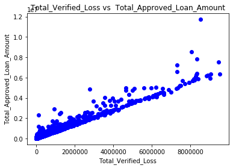

```python
# Scatter plot to see the correlation visually

plt.scatter(dataset.Total_Verified_Loss, dataset.Total_Approved_Loan_Amount,color='blue')
plt.title('Total_Verified_Loss vs  Total_Approved_Loan_Amount')
plt.xlabel('Total_Verified_Loss')
plt.ylabel('Total_Approved_Loan_Amount')
axes = plt.gca()
plt.show()
```

- Note: It is clear from the gaph that the reationship between the variable is LINEAR

# Feature Scaling and Encoding

- Feature scaling is not necessary as both the variables are on the same scale
- Encoding is not necessary as there are no categorical varibles

# Splitting Dataset into Training and Test sets

```python
X=dataset.iloc[:,0:1].values
Y=dataset.iloc[:,1:2].values
```

```python
# splitting the data into training and test set

X_train,X_test,Y_train,Y_test=train_test_split(X,Y,test_size=0.2)
```

```python
print(X_train.shape, Y_train.shape)
print(X_test.shape,Y_test.shape)
```

```
(5241, 1) (5241, 1)
(1311, 1) (1311, 1)
```

## Fitting Linear Regression to the dataset

```python
from sklearn.linear_model import LinearRegression # importing LinearRegression class from skelarn to create its instance

regressor=LinearRegression()
regressor.fit(X_train,Y_train)
```

```
LinearRegression(copy_X=True, fit_intercept=True, n_jobs=None, normalize=False)
```

## Predicting Test set results

```python
Y_pred=regressor.predict(X_test)
```

### Visualizing the training set results

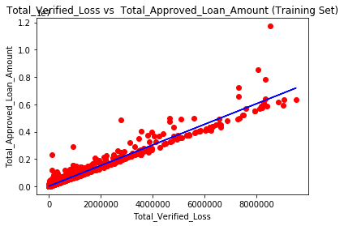

```python
plt.scatter(X_train,Y_train,color='red')
plt.plot(X_train,regressor.predict(X_train),color='blue')
plt.title('Total_Verified_Loss vs  Total_Approved_Loan_Amount (Training Set)')
plt.xlabel('Total_Verified_Loss')
plt.ylabel('Total_Approved_Loan_Amount')
plt.show()
```

### Summary statistics of the linear regression model

```python
print('co-efficients: ', regressor.coef_)
print('Variance score: %.2f'% r2_score(Y_test,Y_pred))
print('Intercept is : %.2f'% regressor.intercept_)
```

```
co-efficients:  [[0.75585615]]
Variance score: 0.97
Intercept is : 15381.48
```

### Visualizing the test set results

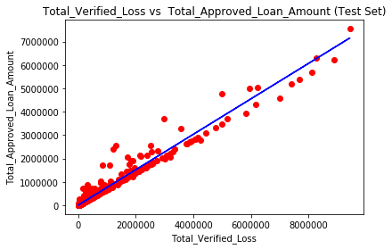

```python
plt.scatter(X_test,Y_test,color='red')
plt.plot(X_test,regressor.predict(X_test),color='blue')
plt.title('Total_Verified_Loss vs  Total_Approved_Loan_Amount (Test Set)')
plt.xlabel('Total_Verified_Loss')
plt.ylabel('Total_Approved_Loan_Amount')
plt.show()
```

```python
pd.options.display.float_format = '{:.2f}'.format
```

### Comparision between ACTUAL and PREDICTION

```python
Actual_vs_Pred = pd.DataFrame({'Actual': Y_test.flatten(), 'Predicted': Y_pred.flatten()})
Actual_vs_Pred .head(20)
```

|  | Actual | Predicted |
| --- | --- | --- |
| 0 | 15900 | 24451.75 |
| 1 | 161800 | 147924.63 |
| 2 | 117000 | 116995.00 |
| 3 | 39100 | 44902.20 |
| 4 | 136089 | 162309.33 |
| 5 | 718400 | 346918.13 |
| 6 | 75000 | 67289.90 |
| 7 | 193300 | 116301.12 |
| 8 | 215174 | 247681.02 |
| 9 | 9544 | 25686.07 |
| 10 | 167800 | 163187.64 |
| 11 | 18900 | 29608.20 |
| 12 | 44400 | 53670.13 |
| 13 | 2760033 | 2994227.95 |
| 14 | 7388 | 23355.76 |
| 15 | 9900 | 25613.50 |
| 16 | 142488 | 169167.22 |
| 17 | 36900 | 43215.88 |
| 18 | 74600 | 86563.48 |
| 19 | 241600 | 272876.73 |

# Decision Tree Classification Model

## To classify/categorize restaurant based on inspection of its cleanliness

Importing the required libraries

```python
import numpy as np                                 # importing numpy library for scientific computations
import pandas as pd                                # importing pandas library for better storage of data
import matplotlib.pyplot as plt                    # importing matplotlib library for visualization
import seaborn as sns                              # importing seaborn library for visualization
from sklearn.tree import DecisionTreeClassifier    # importing DecisionTreeClassifier from sklean to create an instance
from sklearn.metrics import accuracy_score         # importing accuracy_score module from sklearn to check model statistics
from sklearn.preprocessing import LabelEncoder     # importing LabelEncoder module from skelarn to encode categorical variables
sns.set(style="white")                             # formatting the styles of graphs
sns.set(style="whitegrid", color_codes=True)
```

Importing data set

```python
dataset=pd.read_csv('Restaurant_Inspection.csv')
```

```python
dataset.head() # inspecting top 5 recoreds from the  dataset
```

|  | business_id | business_name | business_address | business_city | business_state | business_postal_code | business_latitude | business_longitude | business_location | business_phone_number | ... | violation_id | violation_description | Violation_Category | risk_category | Neighborhoods (old) | Police Districts | Supervisor Districts | Fire Prevention Districts | Zip Codes | Analysis Neighborhoods |
| --- | --- | --- | --- | --- | --- | --- | --- | --- | --- | --- | --- | --- | --- | --- | --- | --- | --- | --- | --- | --- | --- |
| 0 | 97975 | BREADBELLY | 1408 Clement St | San Francisco | CA | 94118 | NaN | NaN | NaN | 1.415724e+10 | ... | 97975_20190725_103124 | Inadequately cleaned or sanitized food contact... | Cleanliness_Risk | Moderate Risk | NaN | NaN | NaN | NaN | NaN | NaN |
| 1 | 95754 | Fools Errand | 639 Divisadero St A | San Francisco | CA | 94117 | NaN | NaN | NaN | NaN | ... | 95754_20190327_103124 | Inadequately cleaned or sanitized food contact... | Cleanliness_Risk | Moderate Risk | NaN | NaN | NaN | NaN | NaN | NaN |
| 2 | 77005 | MoBowL | 428 11th St | San Francisco | CA | 94103 | NaN | NaN | NaN | 1.415964e+10 | ... | 77005_20170429_103120 | Moderate risk food holding temperature | Temperature_Risk | Moderate Risk | NaN | NaN | NaN | NaN | NaN | NaN |
| 3 | 4794 | VICTOR'S | 210 TOWNSEND St | San Francisco | CA | 94107 | 37.778634 | -122.393089 | POINT (-122.393089 37.778634) | 1.415561e+10 | ... | 4794_20181030_103138 | Improper storage use or identification of toxi... | Storage_Risk | Low Risk | 34.0 | 2.0 | 9.0 | 6.0 | 28856.0 | 34.0 |
| 4 | 71440 | New Garden Restaurant, Inc. | 716 Kearny St | San Francisco | CA | 94108 | NaN | NaN | NaN | NaN | ... | 71440_20190401_103150 | Improper or defective plumbing | Infrastructure_Risk | Low Risk | NaN | NaN | NaN | NaN | NaN | NaN |

5 rows × 24 columns

Check for the dimensions of the dataset

```python
dataset.shape
```

```
(36661, 24)
```

Check for the variables

```python
dataset.columns
```

```
Index(['business_id', 'business_name', 'business_address', 'business_city',
       'business_state', 'business_postal_code', 'business_latitude',
       'business_longitude', 'business_location', 'business_phone_number',
       'inspection_id', 'inspection_date', 'inspection_score',
       'inspection_type', 'violation_id', 'violation_description',
       'Violation_Category', 'risk_category', 'Neighborhoods (old)',
       'Police Districts', 'Supervisor Districts', 'Fire Prevention Districts',
       'Zip Codes', 'Analysis Neighborhoods'],
      dtype='object')
```

- It is intuitive from the data that inspection score,Violation_Description, and violation_categroy plays major role in categorizing the restaurant into high_risk,low_risk and moderate_risk based on its cleanliness
- All other features jsut add geographic details of the restaurants
- Violation Category is a derived variable based on Violation_Description using Fuzzy Logic.

### Subsetting the data

```python
dataset=dataset.loc[:,['inspection_score','Violation_Category','risk_category']]
```

```python
dataset.head() # inspecting data with top 5 rows
```

|  | inspection_score | Violation_Category | risk_category |
| --- | --- | --- | --- |
| 0 | 96 | Cleanliness_Risk | Moderate Risk |
| 1 | 84 | Cleanliness_Risk | Moderate Risk |
| 2 | 94 | Temperature_Risk | Moderate Risk |
| 3 | 71 | Storage_Risk | Low Risk |
| 4 | 85 | Infrastructure_Risk | Low Risk |

```python
# Renaming columns
dataset.columns=['Inspection_Score','Violation_Category','Risk_Category']
dataset.columns
```

```
Index(['Inspection_Score', 'Violation_Category', 'Risk_Category'], dtype='object')
```

### Encoding variables

```python
le = LabelEncoder()
dataset['Risk_Category']= le.fit_transform(dataset['Risk_Category'])
dataset['Violation_Category']= le.fit_transform(dataset['Violation_Category'])

# Risk_Category: High Risk(0),Low Risk(1),Moderate Risk(2)
```

```python
dataset.head() # inspecting top 5 rows
```

|  | Inspection_Score | Violation_Category | Risk_Category |
| --- | --- | --- | --- |
| 0 | 96 | 4 | 2 |
| 1 | 84 | 4 | 2 |
| 2 | 94 | 31 | 2 |
| 3 | 71 | 30 | 1 |
| 4 | 85 | 16 | 1 |

### Subsetting Data and Splitting data into training and test set

```python
# Creating array of Independent variables and Target Varaibles
X=dataset.iloc[:,0:2].values
Y=dataset.iloc[:,-1].values
```

```python
# Printing the number of records by Risk_Category, i.e the number restaurants belonging to each risk group
(unique, counts) = np.unique(Y, return_counts=True)
frequencies = np.asarray((unique, counts)).T
frequencies
```

```
array([[    0,  5222],
       [    1, 17407],
       [    2, 14032]], dtype=int64)
```

### Splitting the data into training and test sets

```python
from sklearn.model_selection import train_test_split #splitting the data into training and test set using train_test_split class
X_train,X_test,Y_train,Y_test=train_test_split(X,Y,test_size=0.2)
```

```python
# Checking the dimension of the training and test sets
print(X_train.shape, Y_train.shape)
print(X_test.shape,Y_test.shape)
```

```
(29328, 2) (29328,)
(7333, 2) (7333,)
```

### Fitting the DecisionTreeClassifier class to the training data

```python
# Creating an instance of the class DecisionTreeClassifier
Decision_Tree_Classifier = DecisionTreeClassifier(random_state=10)

# fit the model with the training data
Decision_Tree_Classifier.fit(X_train,Y_train)
```

```
DecisionTreeClassifier(ccp_alpha=0.0, class_weight=None, criterion='gini',
                       max_depth=None, max_features=None, max_leaf_nodes=None,
                       min_impurity_decrease=0.0, min_impurity_split=None,
                       min_samples_leaf=1, min_samples_split=2,
                       min_weight_fraction_leaf=0.0, presort='deprecated',
                       random_state=10, splitter='best')
```

```python
# Depth of the decision tree

print('Depth of the Decision tree :', Decision_Tree_Classifier.get_depth())
```

```
Depth of the Decision tree : 29
```

```python
# Predicting the target on the training dataset

predict_train = Decision_Tree_Classifier.predict(X_train)
print('Prediction on training data',predict_train)
```

```
Prediction on training data [1 1 1 ... 2 1 1]
```

```python
# Confusion Matrix for the prediction on training set

from sklearn.metrics import confusion_matrix  # importing confusion matrix from sklearn.metrics to check the accuracy
cm=confusion_matrix(Y_train,predict_train)
cm
```

```
array([[ 3251,    69,   851],
       [  334, 12970,   645],
       [  968,  1472,  8768]], dtype=int64)
```

```python
# Accuray Score on predecting target for training dataset

accuracy_train = accuracy_score(Y_train,predict_train)
print('Accuracy score on predecting target for training dataset : ', accuracy_train)
```

```
Accuracy score on predecting target for training dataset :  0.8520526459356247
```

```python
# Predicting the target on the test dataset

predict_test = Decision_Tree_Classifier.predict(X_test)
print('Prediction on test data',predict_test)
```

```
Prediction on test data [2 1 1 ... 1 0 0]
```

```python
# Accuracy Score on predecting target for training dataset

accuracy_test = accuracy_score(Y_test,predict_test)
print('Accuracy score on predecting target for testing dataset : ', accuracy_test)
```

```
Accuracy score on predecting target for testing dataset :  0.8430383199236329
```

```python
# calculating recall on test dataset

from sklearn.metrics import recall_score
recall = recall_score(Y_test, predict_test, labels=[1,2], average='micro')
print('Recall: %.3f' % recall)
```

```
Recall: 0.852
```

```python
# Calculating precision score on test dataset

from sklearn.metrics import precision_score
precision = precision_score(Y_test, predict_test, labels=[1,2], average='micro')
print('Precision: %.3f' % precision)
```

```
Precision: 0.872
```